# Information Management Database Project Report

> Instructor: Dr. Karl Ho

> Min Shi

> May 12, 2022

# Database Topic: US-China Trade Database

# Database Introduction

The database aims to serve people interested in US-China trade war and its effect on US-China trade volumes, and the impact on US multinational corporations (MNCs) which depend on global value chains (GVC) heavily.

The database provides mainly two types of data. The first type is the macroscopic data. Specifically, this database provides US-China monthly trade data by commodity, the volume and percentage of products under tariff data between US and China. It also contains the data about US annual trade with all countries and the basic development indicator information of these countries, including GDP, population, tariff rate in general, and tariff rate for manufactured products. The second type of data is the microcosmic data about MNCs, including S&P 500 company list with detailed information, such as stock symbol, location, sector, industry, etc., S&P 500 company stock price time-series data, fortune 500 company list and their annual revenues data, fortune 500 company stock price time-series data, top 20 companies list based on their level of sale in China, and top 20 companies list based on their share of sale in China.

People could utilize this dataset to explore how U.S.-China trade relations change in the 21st century, the connection between U.S.-China trade and their tariff change, the differences in the tendencies of US trade with different companies, how U.S.-China trade relations affect U.S. multinational corporations (MNCs).

# Background Introduction

The trade between the U.S. and China started since 1971 when the U.S. officially ended its trade embargo on China. In 1979, when the two sides officially re-established diplomatic relations and signed a bilateral trade agreement, the U.S.-China trade volume began to grow. In 2001, China's entry into the World Trade Organization (WTO) changed China's economy to an export-driven pattern, contributing to China's rapid development of its economy and international trade (Wang 2013). The U.S. has become the largest destination for China's exports since 2000 (Shen et al. 2020). During the first decade of the twenty-first century, both U.S. and China attach great importance to their economic cooperation, and their trade relations have expanded rapidly. From China's side, bilateral trade with the U.S. and foreign investment from the U.S. side is crucial for China's continuous development and modernization. From the perspective of the U.S., China's rapid development speed brings enormous potential market and economic activity while the government begins to raise a concern about its national security (Wang 2013).

In 2010, China became the second-largest economy after the U.S. in terms of GDP. Since the Obama administration, the U.S. has treated China as the biggest challenger and a strategic competitor. After Donald Trump took office in 2017, the U.S. government focused on the trade unbalance between the U.S. and China. In January 2018, U.S. President Donald Trump began imposing tariffs and other trade barriers on China to force it to change what the U.S. calls "unfair trade practices" and theft of intellectual property (Wikipedia Foundation, 2021), which is a signal for the following outbreak of the U.S.-China trade war.

U.S. and China relations have worsened in the past few years, starting from the U.S.-China trade war. The imposed tariffs from both sides impede the normal GVC circulation, increase the manufacturing cost, and further reduce the profits margins of U.S. MNCs. Moreover, worsened U.S.-China relations bring growing anti-U.S. sentiment in China and raises the risk of nationalistic reactions and boycotts, which affect the sales of U.S. MNC productions in China, which holds the world’s largest markets for retail, chemicals, chips, and other industries (Kapadia, 2021).

Thus, utilizing macroscopic and microcosmic data to explore the U.S.-China trade status and the revenues of MNCs overtime is necessary to evaluate the effect of the U.S.-China trade war on the economy.

# US-China Trade Database Schema

This database includes thirteen tables and the relations among these tables are shown in the ER diagram below.

Database ER Diagram

[figure not shown]

# Database Implementation

The database implementation is mainly through the R Shiny app \& python.

As for the Shiny app, I inner join the fortune500stockPrice Table and SP500withGICS Table on the Symbol column and generate a combined table about the daily time-series stock data of the public companies within the Fortune 500 list between 2017-01-01 and 2021-09-09 with 423,753 rows and seven columns, including symbol, company name, headquarter location, sector, industry, Date, AdjClose.

The results could be accessed through the shiny app [link](https://minshimia.shinyapps.io/Shiny/?_ga=2.266600647.890102784.1652257861-1346453525.1649978871) and the screenshot below shows what the Shiny App looks like.

R Shiny App Example

[figure not shown]

As for python implementation, I connect to postgresql database through two steps. Firstly, I install ipython-sql package, and this package introduces a %sql (or %%sql) magic to your notebook, allowing you to connect to a database. Secondly, I install psycopg2 package, the most popular PostgreSQL database adapter for the Python programming language.

## Using sql "magic" to connect to Postgresql

```python
#!pip install ipython-sql
```

```python
#!pip install psycopg2
```

```python
#!pip install nbconvert
```

```python
#!brew install pandoc
```

```python
%load_ext sql
```

```python
%sql postgresql://postgres:******@127.0.0.1:5433/6354Database
```

```python
import seaborn as sns
import matplotlib.pyplot as plt
import pandas as pd
import numpy as np
import re
import warnings
warnings.filterwarnings('ignore')
```

After connecting to PostgreSQL, I could extract data from the database using SQL command. Next, I use pandas and NumPy packages to deal with the data extracted. Besides, I use matplotlib and seaborn packages to do statistical visualization. Finally, the statsmodels package is utilized to do time-series analysis.

And the following part shows some data analysis examples.

## Data Analysis 1 -- Exploring Annual Country GDP and Tariffs and US Trade with China Compared to Other Countries

```python
%%sql result_set1_1 <<
select * from countryDevelopmentIndicator cdi
where cdi.year >= '2014-01-01'
```

```
 * postgresql://postgres:***@127.0.0.1:5433/6354Database
1519 rows affected.
Returning data to local variable result_set1_1
```

```python
df1_1 = result_set1_1.DataFrame()
df1_1['year'] = df1_1['year'].astype('datetime64')
df1_1.head()
```

|  | countryname | countrycode | year | gdp | population | tariffall | tariffmanufactured |
| --- | --- | --- | --- | --- | --- | --- | --- |
| 0 | Barbados | BRB | 2017-01-01 | 4978000000.00 | 286229.00 | None | None |
| 1 | Aruba | ABW | 2015-01-01 | 2962905028.00 | 104339.00 | 10.02 | 11.09 |
| 2 | Afghanistan | AFG | 2015-01-01 | 19134211764.00 | 34413603.00 | None | None |
| 3 | Albania | ALB | 2015-01-01 | 11386850130.00 | 2880703.00 | 3.58 | 0.66 |
| 4 | Algeria | DZA | 2015-01-01 | 165979279263.00 | 39728020.00 | 12.02 | 7.66 |

```python
%%sql result_set1_2 <<
select * from UStradebyCountryYear ust
where ust.year >= '2014-01-01'
```

```
 * postgresql://postgres:***@127.0.0.1:5433/6354Database
1627 rows affected.
Returning data to local variable result_set1_2
```

```python
df1_2 = result_set1_2.DataFrame()
df1_2['year'] = df1_2['year'].astype('datetime64')
df1_2.head()
```

|  | countryname | year | imports | exports | balance |
| --- | --- | --- | --- | --- | --- |
| 0 | Afghanistan | 2015-01-01 | 23601251 | 478711524 | 455110273 |
| 1 | Afghanistan | 2016-01-01 | 33715926 | 913874351 | 880158425 |
| 2 | Afghanistan | 2017-01-01 | 14423622 | 942232031 | 927808409 |
| 3 | Afghanistan | 2018-01-01 | 29408728 | 1227404432 | 1197995704 |
| 4 | Afghanistan | 2019-01-01 | 38744074 | 757769159 | 719025085 |

```python
df1 = pd.merge(df1_1, df1_2, left_on = ['countryname', 'year'], right_on = ['countryname', 'year'], how = 'left')
df1['gdp'] = df1['gdp']/1000000
df1['population'] = df1['population']/1000000
df1['imports'] = df1['imports']/1000000
df1['exports'] = df1['exports']/1000000
df1['balance'] = df1['balance']/1000000
```

```python
ilocList = []
for i in range(len(df1['countryname'])):
    if df1.iloc[i]['countryname'] in ['China', 'United States', 'Japan', 'United Kingdom', 'France', 'Germany', 'Canada','Mexico']:
        ilocList.append(i)
```

```python
df1_3 = df1.iloc[ilocList]
df1_3.sort_values(by = 'countryname')
df1_3.head()
```

|  | countryname | countrycode | year | gdp | population | tariffall | tariffmanufactured | imports | exports | balance |
| --- | --- | --- | --- | --- | --- | --- | --- | --- | --- | --- |
| 35 | Canada | CAN | 2015-01-01 | 1556508.816217 | 35.702908 | 3.11 | 1.12 | 296000 | 280855 | -15145 |
| 41 | China | CHN | 2015-01-01 | 11061553.079872 | 1379.86 | 5.58 | 5.70 | 483000 | 115873 | -367127 |
| 67 | France | FRA | 2015-01-01 | 2439188.643163 | 66.548272 | 3.09 | 2.26 | 47808.780079 | 30026.310133 | -17782.469946 |
| 99 | Japan | JPN | 2015-01-01 | 4444930.651964 | 127.141 | 2.83 | 1.47 | 131000 | 62387.809646 | -68612.190354 |
| 108 | Germany | DEU | 2015-01-01 | 3357585.719352 | 81.686611 | 3.09 | 2.26 | 125000 | 49978.833642 | -75021.166358 |

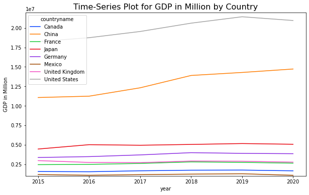

```python
plt.figure(figsize = (10, 6))
sns.lineplot(x="year", y = 'gdp', hue="countryname", palette = 'bright', data = df1_3)
plt.ylim(1000000, 22000000)
plt.xlabel('year')
plt.ylabel('GDP in Million')
plt.title('Time-Series Plot for GDP in Million by Country', fontsize = 16)
plt.show()
# plt.savefig('Figure1.png')
```

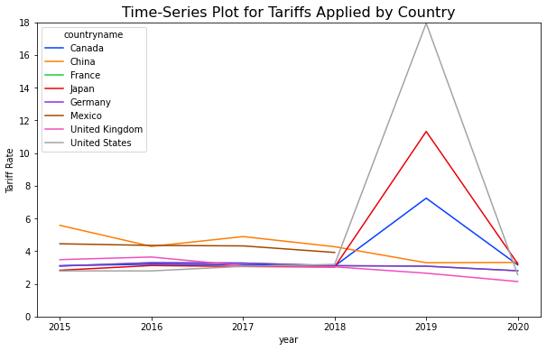

```python
plt.figure(figsize = (10, 6))
sns.lineplot(x="year", y = 'tariffall', hue="countryname", palette = 'bright', data = df1_3)
plt.ylim(0, 18)
plt.xlabel('year')
plt.ylabel('Tariff Rate')
plt.title('Time-Series Plot for Tariffs Applied by Country', fontsize = 16)
plt.show()
# plt.savefig('Figure2.png')
```

```python
ilocList2 = []
for i in range(len(df1['countryname'])):
    if df1.iloc[i]['countryname'] in ['China', 'Japan', 'United Kingdom', 'France', 'Germany', 'Canada', 'Mexico']:
        ilocList2.append(i)
```

```python
df1_4 = df1.iloc[ilocList2]
df1_4.sort_values(by = 'countryname')
df1_4.head()
```

|  | countryname | countrycode | year | gdp | population | tariffall | tariffmanufactured | imports | exports | balance |
| --- | --- | --- | --- | --- | --- | --- | --- | --- | --- | --- |
| 35 | Canada | CAN | 2015-01-01 | 1556508.816217 | 35.702908 | 3.11 | 1.12 | 296000 | 280855 | -15145 |
| 41 | China | CHN | 2015-01-01 | 11061553.079872 | 1379.86 | 5.58 | 5.70 | 483000 | 115873 | -367127 |
| 67 | France | FRA | 2015-01-01 | 2439188.643163 | 66.548272 | 3.09 | 2.26 | 47808.780079 | 30026.310133 | -17782.469946 |
| 99 | Japan | JPN | 2015-01-01 | 4444930.651964 | 127.141 | 2.83 | 1.47 | 131000 | 62387.809646 | -68612.190354 |
| 108 | Germany | DEU | 2015-01-01 | 3357585.719352 | 81.686611 | 3.09 | 2.26 | 125000 | 49978.833642 | -75021.166358 |

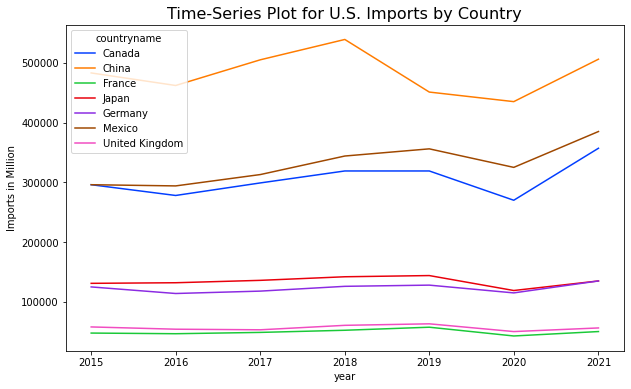

```python
plt.figure(figsize = (10, 6))
sns.lineplot(x="year", y = 'imports', hue="countryname", palette = 'bright', data = df1_4)
plt.xlabel('year')
plt.ylabel('Imports in Million')
plt.title('Time-Series Plot for U.S. Imports by Country', fontsize = 16)
plt.show()
# plt.savefig('Figure3.png')
```

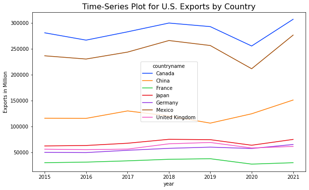

```python
plt.figure(figsize = (10, 6))
sns.lineplot(x="year", y = 'exports', hue="countryname", palette = 'bright', data = df1_4)
plt.xlabel('year')
plt.ylabel('Exports in Million')
plt.title('Time-Series Plot for U.S. Exports by Country', fontsize = 16)
plt.show()
# plt.savefig('Figure4.png')
```

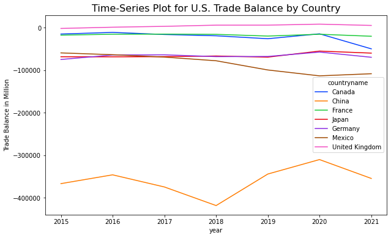

```python
plt.figure(figsize = (10, 6))
sns.lineplot(x="year", y = 'balance', hue="countryname", palette = 'bright', data = df1_4)
plt.xlabel('year')
plt.ylabel('Trade Balance in Million')
plt.title('Time-Series Plot for U.S. Trade Balance by Country', fontsize = 16)
plt.show()
# plt.savefig('Figure5.png')
```

## Data Analysis 2 -- Exploring US-China Trade by Commodity and Sectors

```python
%%sql result_set2 <<
select tc.htsnumber, tc.month, tc.imports, tc.exports, tc.balance, tc. sector, cn.description
from USChinatradebyCommoditySectorMonthly tc
inner join commoditybyhtsnumber cn
on tc.htsnumber = cn.htsnumber
where tc.month >= '2017-01-01';
```

```
 * postgresql://postgres:***@127.0.0.1:5433/6354Database
6014 rows affected.
Returning data to local variable result_set2
```

```python
df2 = result_set2.DataFrame()
df2['month'] = df2['month'].astype('datetime64').dt.year
```

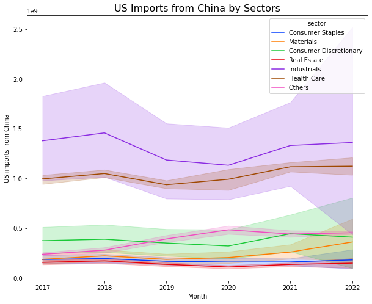

```python
plt.figure(figsize = (10, 8))
sns.lineplot(x="month", y = 'imports', hue="sector", palette = 'bright', data = df2)
plt.xlabel('Month')
plt.ylabel('US imports from China')
plt.title('US Imports from China by Sectors', fontsize = 16)
plt.show()
# plt.savefig('Figure6.png')
```

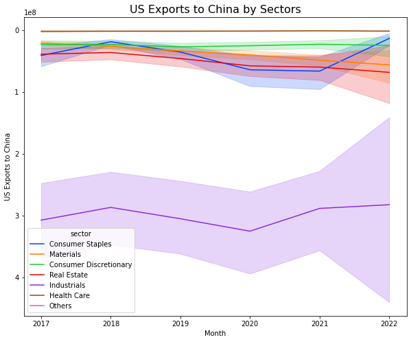

```python
plt.figure(figsize = (10, 8))
sns.lineplot(x="month", y = 'exports', hue="sector", palette = 'bright', data = df2)
plt.xlabel('Month')
plt.ylabel('US Exports to China')
plt.title('US Exports to China by Sectors', fontsize = 16)
plt.show()
# plt.savefig('Figure7.png')
```

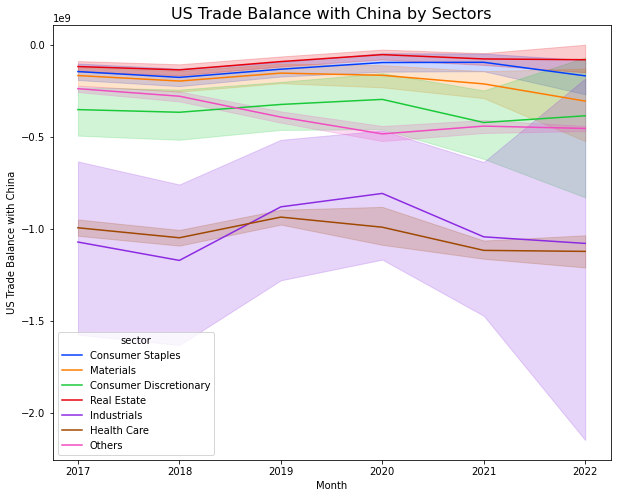

```python
plt.figure(figsize = (10,8))
sns.lineplot(x="month", y = 'balance', hue="sector", palette = 'bright', data = df2)
plt.xlabel('Month')
plt.ylabel('US Trade Balance with China')
plt.title('US Trade Balance with China by Sectors', fontsize = 16)
plt.show()
# plt.savefig('Figure8.png')
```

## Data Analysis 3 -- Exploring US-China Trade Tariff Data during Trade War Period

```python
%%sql result_set3 <<
select trc.TariffAction, trc.Date, trc.ChineseTariffsOnUSExports, trc.ChineseTariffsOnROWExports, trc.USTariffsOnChineseExports,
trc.USTariffsOnROWExports, tc.ChineseExportsSubjectToUSTariffs, tc.USExportsSubjectToChineseTariffs,
trc.TradeWar, trc.PhaseOneAgreement
from USChinaTariffRateChange trc
inner join USChinaTradeTariffCoverage tc
on trc.date = tc.date;
```

```
 * postgresql://postgres:***@127.0.0.1:5433/6354Database
38 rows affected.
Returning data to local variable result_set3
```

```python
df3 = result_set3.DataFrame()
df3.head()
```

|  | tariffaction | date | chinesetariffsonusexports | chinesetariffsonrowexports | ustariffsonchineseexports | ustariffsonrowexports | chineseexportssubjecttoustariffs | usexportssubjecttochinesetariffs | tradewar | phaseoneagreement |
| --- | --- | --- | --- | --- | --- | --- | --- | --- | --- | --- |
| 0 | 1-Jan-18 | 2018-01-01 | 8.0 | 8.0 | 3.1 | 2.2 | 0.0 | 0.0 | NaN | NaN |
| 1 | US Section 201 tariffs on solar panels and was... | 2018-02-07 | 8.0 | 8.0 | 3.2 | 2.2 | 0.2 | 0.0 | NaN | NaN |
| 2 | US Section 232 tariffs on steel and aluminum, ... | 2018-03-23 | 8.0 | 8.0 | 3.8 | 2.5 | 0.8 | 0.0 | NaN | NaN |
| 3 | China's retaliation to US Section 232 tariffs | 2018-04-02 | 8.0 | 8.4 | 3.8 | 2.5 | 0.8 | 1.9 | NaN | NaN |
| 4 | China's MFN tariff cut on pharmaceuticals | 2018-05-01 | 8.0 | 8.3 | 3.8 | 2.5 | 0.8 | 1.9 | NaN | NaN |

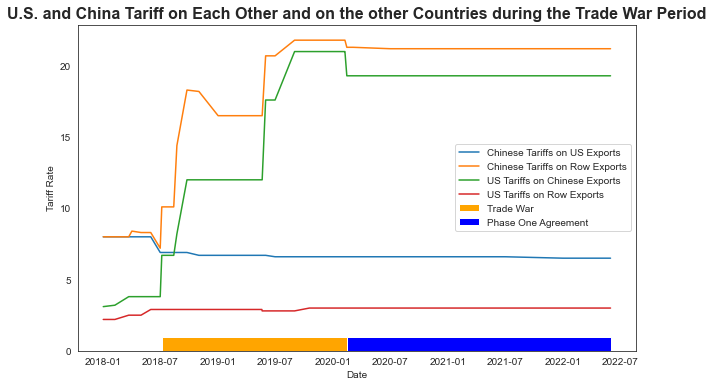

```python
plt.figure(figsize = (10, 6))
sns.set_style("white")
sns.lineplot(data=df3, x="date", y="chinesetariffsonusexports")
sns.lineplot(data=df3, x="date", y="chinesetariffsonrowexports")
sns.lineplot(data=df3, x="date", y="ustariffsonchineseexports")
sns.lineplot(data=df3, x="date", y="ustariffsonrowexports")

color_map = ['orange']
plt.stackplot(df3.date, df3.tradewar,colors=color_map)
color_map = ['blue']
plt.stackplot(df3.date, df3.phaseoneagreement,colors=color_map)
plt.legend(labels=["Chinese Tariffs on US Exports", "Chinese Tariffs on Row Exports",
                   "US Tariffs on Chinese Exports", "US Tariffs on Row Exports",
                   'Trade War', 'Phase One Agreement'])
plt.xlabel('Date')
plt.ylabel('Tariff Rate')
plt.title('U.S. and China Tariff on Each Other and on the other Countries during the Trade War Period',  weight = 'bold', fontsize = 16)
# plt.savefig('Figure.png')
plt.show()
# plt.savefig('Figure9.png')
```

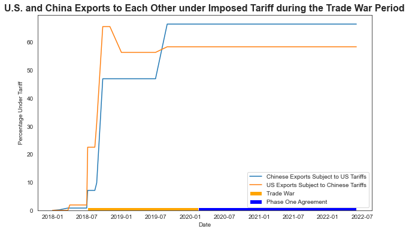

```python
plt.figure(figsize = (10, 6))
sns.set_style("white")
sns.lineplot(data=df3, x="date", y="chineseexportssubjecttoustariffs")
sns.lineplot(data=df3, x="date", y="usexportssubjecttochinesetariffs")
color_map = ['orange']
plt.stackplot(df3.date, df3.tradewar,colors=color_map)
color_map = ['blue']
plt.stackplot(df3.date, df3.phaseoneagreement,colors=color_map)
plt.legend(labels=["Chinese Exports Subject to US Tariffs", "US Exports Subject to Chinese Tariffs",
                  'Trade War', 'Phase One Agreement'])
plt.xlabel('Date')
plt.ylabel('Percentage Under Tariff')
plt.title('U.S. and China Exports to Each Other under Imposed Tariff during the Trade War Period',  weight = 'bold', fontsize = 16)
# plt.savefig('Figure.png')
plt.show()
# plt.savefig('Figure10.png')
```

**From the above plots, we can see the tariff rates of the U.S. and China on each other before the trade war was relatively low, specifically 3% tariff rate from the U.S. side and an 8% tariff rate from China's side. During the tariff trade period (orange), the tariff rates have been increased through several phases. I mainly divide the whole period into four phases, and the following paragraphs introduce the four phases in detail.**

In the first stage, the U.S. announced a preliminary tariff list for the imports from China on April 3, 2018, worth U.S. \$ 50 billion (list 1 \& list 2); China also announced a list of the same amount on the second day. The final lists were decided in June and implemented in July (list 1) and August (list 2), 2018 (Wong \& Koty, 2020).

In the second stage, the U.S. side announced the tariff plan on another list of Chinese goods (List 3) which are worth US\$ 200 billion on September 17, 2018; China announced the tariff on US\$ 60 billion worth of U.S. goods on the next day. The tariffs on both sides came into effect on September 24, 2018. Later, in June 2019, the tariff rates from both sides increased to 25\% (Mullen, 2021).

In the third stage of the trade war, the U.S. has announced tariffs on an additional US\$ 300 billion worth of Chinese exports to the U.S. on August 13, 2019, and China used retaliatory measures, and announced tariffs on US\$ 75 billion worth of American goods on August 23, 2019 (Liang & Ding 2020: 41-44). And the U.S. started implementing tariffs on more than US \$125 billion worth of Chinese products (list 4A) on September 1, 2019. China also imposed retaliated tariffs on a subset of the scheduled list.

The signature of the Phase One Deal marked the U.S.-China trade war marching into the next stage. Under the agreement, China agrees to purchase an additional \$200 billion worth of U.S. products. Besides, the U.S. and China reduce some tariffs on some exports from the other side. But the U.S.-China Phase One Deal plan does not go smoothly. Due to the pandemic, China only finished 59\% of its 2020 purchasing U.S. products goal. As the Biden administration started, several trade talks were held, but there was still no bright signal of lifting all imposed tariffs. Until the end of 2021, China bought only 57\% of the U.S. exports it had committed to purchase under the Phase One Deal. In February 2022, the U.S. House of Representatives passed America Competes Act, aiming to strengthen the U.S. competitive edge over China. Besides, U.S. Trade Representative (USTR) puts more effort into competing with China in an annual report (China Briefing Team, 2022).

## Data Analysis 4 -- Exploring the S&P 500 Companies with GICS classification

The Global Industry Classification Standard (GICS) is a four-tiered, hierarchical industry classification system developed in 1999 by MSCI and Standard & Poor's (S&P) Dow Jones Indices for use by the global financial community. The GICS structure consists of

- 11 sectors
- 24 industry groups
- 69 industries
- 158 sub-industries.

And S&P has categorized all major public companies. GICS is used as a basis for S&P and MSCI financial market indexes in which each company is assigned to a sub-industry, and to an industry, industry group, and sector, by its principal business activity.

"GICS" is a registered trademark of McGraw Hill Financial and MSCI Inc.

```python
%%sql result_set4 <<
select * from sp500withgics;
```

```
 * postgresql://postgres:***@127.0.0.1:5433/6354Database
505 rows affected.
Returning data to local variable result_set4
```

```python
df4 = result_set4.DataFrame()
df4['datefirstadded'] = df4['datefirstadded'].astype('datetime64')
df4['datefirstadded'] = pd.to_datetime(df4['datefirstadded'])
df4['yearfirstadded'] = df4['datefirstadded'].dt.year
```

```python
df4['hqlocation'] = df4['hqlocation'].apply(lambda x: re.split(r',', x)[1])
df4['hqlocation'] = df4['hqlocation'].apply(lambda x: re.split(r'\;|\[', x)[0])
```

```python
df4_1 = df4.groupby(['hqlocation']).count()
df4_1['Number of Companies in that location'] = df4_1['symbol']
df4_1 = df4_1[['Number of Companies in that location']].sort_values(by = 'Number of Companies in that location', ascending = False)
df4_1.head(10)
```

| hqlocation | Number of Companies in that location |
| --- | --- |
| California | 78 |
| New York | 56 |
| Texas | 38 |
| Illinois | 34 |
| Massachusetts | 21 |
| Ohio | 19 |
| Georgia | 17 |
| Pennsylvania | 17 |
| New Jersey | 16 |
| North Carolina | 16 |

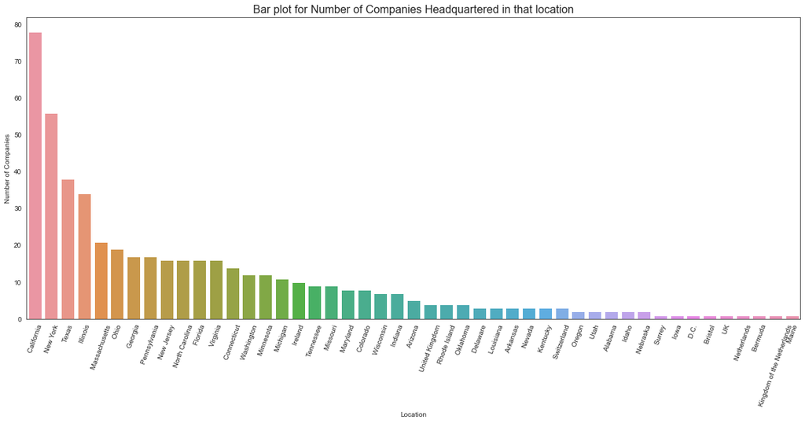

```python
plt.figure(figsize = (20, 8))
sns.barplot(x = df4_1.index, y = 'Number of Companies in that location', data = df4_1)
plt.xticks(rotation=70)
plt.xlabel('Location')
plt.ylabel('Number of Companies')
plt.title('Bar plot for Number of Companies Headquartered in that location', fontsize = 16)
plt.show()
# plt.savefig('Figure11.png')
```

```python
df4_2 = df4.groupby(['sector']).count()
```

```python
df4_2['Number of Companies in the sector'] = df4_2['symbol']
df4_2 = df4_2[['Number of Companies in the sector']].sort_values(by = 'Number of Companies in the sector', ascending = False)
df4_2.head(11)
```

| sector | Number of Companies in the sector |
| --- | --- |
| Information Technology | 74 |
| Industrials | 73 |
| Financials | 65 |
| Health Care | 63 |
| Consumer Discretionary | 61 |
| Consumer Staples | 32 |
| Real Estate | 30 |
| Materials | 28 |
| Utilities | 28 |
| Communication Services | 26 |
| Energy | 25 |

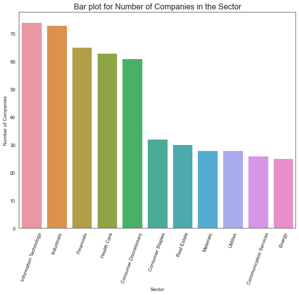

```python
plt.figure(figsize = (10, 8))
sns.barplot(x = df4_2.index, y = 'Number of Companies in the sector', data = df4_2)
plt.xticks(rotation=70)
plt.xlabel('Sector')
plt.ylabel('Number of Companies')
plt.title('Bar plot for Number of Companies in the Sector', fontsize = 16)
plt.show()
# plt.savefig('Figure12.png')
```

**As for the number of companies by eleven sectors, information technology and industrial have more than 70 S&P 500 companies, followed by financial, health care, and consumer discretionary, including approximately 60 S&p 500 companies. The other six sectors contain approximately 30 S&P 500 companies.**

**Combing the result from the analysis of U.S.-China trade by sectors, I suppose that the tendencies of changes in companies' annual revenues and stock prices tend to be similar within one sector but are more likely to be different among sectors. Next, I will firstly combine fortune 500 annual revenue data with the S&P 500 company list with GISC information to analyze the time series revenue changes by sector. Secondly, I will combine stock data with the S&P 500 company list with GISC information to analyze the time series stock data by sector.**